# Statistika skupinového chatu

vyrobil Petr Zahradník

Mimochodem v historii se dají najít opravdové poklady. Náhodou jsem narazil třeba na:

> Schreibi: Jsi debil, end of the story

nebo

> Fíša: Já jdu orat pole kdyby vás to zajímalo

nebo

> Sára: Zavřeli mu kebabárnu

> Martina: Jakou?

> Sára: Jak z ní byl víc udělanej než z holky

> Klára: Sáro...

> Šimon: Fuj

> Sára: No tak vždyť o tom básní skoro kazdou přestávku o ty kebabárně, ježiši vy ze mě hned uděláte úchyla

> Martina: Ty jseš uchyl

> Martina: Ale na druhou stranu, Radek opravdu mluvi o tom kebabu jako o blowjobu

> Sára: Druhej úchyl se ozval

nebo

> Nikol: Běžte doprdele zasekali jste mi mobil!!!!!

nebo

> Dali: Poradím vám jednu věc. Nikdy nedělejte donuts. Je to pěkná sračka. Těsto je na hovno a nakonec budete mít mouku politou cukrem a posypanou zdobením...

nebo

> Michal: Kvůli rodině jsem vstal pozdě a nestihl autobus :d

> P.Z.: #NaNikolu

nebo

> P.Z.: hmm, nebude to barvou vlasů? nebo tou řasenkou? asi by sis měl změnit jméno na Michal Michchi Galbavý :)

> Michal: Spíš Michal Dámvšem Galbavý

```python
# -*- coding: utf-8 -*-
import json
import numpy as np
import pandas as pd
import matplotlib.pyplot as plt
import matplotlib.font_manager as font_manager
import emoji
```

```python
plt.rcParams['figure.figsize'] = [15, 6]
plt.rcParams.update({'font.size': 16})
with open('i:/blbosti/archiv-messenger/inbox/bombaktava_va3ie5f-la/message_1_dec.json', encoding='utf8') as json_file:
    json_raw = json.load(json_file)
messages_raw = pd.io.json.json_normalize(json_raw['messages'])
msg = messages_raw[['timestamp_ms', 'type', 'sender_name', 'content']].dropna()
```

```python
print('Vstupní data:')
msg
```

```
Vstupní data:
```

|  | timestamp_ms | type | sender_name | content |
| --- | --- | --- | --- | --- |
| 1 | 1557052944966 | Generic | Fiserova Adela | Máte někdo prosiiim seznam témat na ájinu?🙏 |
| 2 | 1556904046174 | Generic | Sara Masopustova | Dík |
| 3 | 1556904044216 | Generic | Sara Masopustova | Ok |
| 4 | 1556904037742 | Generic | Michal Galbavý | Protože tam bylo "napište z textu" |
| 5 | 1556904033739 | Generic | Martina Fárová | Ne to neni chyba |
| 6 | 1556904027905 | Generic | Michal Galbavý | Ja napsal lůzy |
| 7 | 1556904025473 | Generic | Sara Masopustova | Bylo* |
| 8 | 1556904022535 | Generic | Sara Masopustova | Ja to napsala, tak jak to byla v tom textu |
| 9 | 1556904015219 | Generic | Sara Masopustova | Hele musela tam bejt lůza? Kdyz máme lůzy, tak... |
| 10 | 1556903984144 | Generic | Týna Loubalová | Když si je můžeš nechat |
| 11 | 1556903973748 | Generic | Týna Loubalová | Jen nechápu, proč nám sebrali ty zadání |
| 12 | 1556903486937 | Generic | Simon Kolecek | Jj |
| 13 | 1556903477800 | Generic | Michal Galbavý | 46 je ještě 1 ne? |
| 14 | 1556903471789 | Generic | Michal Galbavý | :D |
| 15 | 1556903469306 | Generic | Michal Galbavý | Kolik mate bodu z didaktaku? |
| 16 | 1556902294615 | Generic | Michal Galbavý | @Honza Mátl @Petr Zahradník @Karel Leufen půjd... |
| 17 | 1556898731709 | Generic | Dalibor Pelčák | Jako mně mají přijet prarodiče z Moravy, ale j... |
| 18 | 1556898650808 | Generic | Kateřina Kubecová | jakoze...nasi asi teda neprijdou😂😂😂 |
| 19 | 1556897962562 | Generic | Adéla Schreiberová | Just.... why? |
| 20 | 1556897932381 | Generic | Adéla Schreiberová | Me by zajimala jeji motivace k tomu, tohle udelat |
| 21 | 1556897005880 | Generic | Simon Kolecek | Ne že by tam někdo byl |
| 22 | 1556896999696 | Generic | Simon Kolecek | Jj, v 17 hodin pak všichni před školou, jasný? |
| 23 | 1556896956868 | Generic | Sara Masopustova | Až 21 v 17 h protestujte pls |
| 24 | 1556896832665 | Generic | Petr Zahradník | Mu ještě zkazíme dovolenou tvl |
| 25 | 1556896818673 | Generic | Simon Kolecek | Sounds familiar? 😂 |
| 26 | 1556896810950 | Generic | Simon Kolecek | To řekneme šidákovi a ještě nám bude vyhrožova... |
| 27 | 1556896766961 | Generic | Martina Fárová | Fakt myslis, Dali😁 |
| 28 | 1556896745135 | Generic | Dalibor Pelčák | Vždyť můžeme přece sdělit svůj nesouhlas |
| 29 | 1556896691047 | Generic | Simon Kolecek | Ty vysvědčení se rozdávají nám, ne jim... ne? |
| 30 | 1556896682208 | Generic | Sara Masopustova | Hlavne rodice tam prijdou jen kvuli nam |
| ... | ... | ... | ... | ... |
| 28142 | 1460656455284 | Generic | Michal Galbavý | :D |
| 28143 | 1460656450851 | Generic | Nikol Janatová | On je roztrojená osobnost  |
| 28144 | 1460656443130 | Generic | Martina Fárová | *udelal |
| 28145 | 1460656435233 | Generic | Martina Fárová | To ty jsi z chudaka Kaji udelala rozdvojenou o... |
| 28146 | 1460656401620 | Generic | Michal Galbavý | schizofrenie? |
| 28147 | 1460656365431 | Generic | Karel Leufen | Pepa spí. Teď jsem Karel |
| 28148 | 1460656349490 | Generic | Michal Galbavý | pepo klid |
| 28149 | 1460656337805 | Generic | Karel Leufen | Fuck you all |
| 28150 | 1460656306432 | Generic | Michal Galbavý | neodsuzuji* |
| 28151 | 1460656298346 | Generic | Michal Galbavý | já nikoho neudsuzuji |
| 28152 | 1460656293362 | Generic | Michal Galbavý | :D |
| 28153 | 1460656279728 | Generic | Fiserova Adela | Nic proti Kajo.. |
| 28154 | 1460656266633 | Generic | Fiserova Adela | Asi by to chtelo se teda nejak domluvit nez tu... |
| 28155 | 1460656228087 | Generic | Karel Leufen |  |
| 28156 | 1460656224765 | Generic | Karel Leufen | Debil |
| 28157 | 1460656194360 | Generic | Michal Galbavý | to zni německy |
| 28158 | 1460656191686 | Generic | Michal Galbavý | fuj |
| 28159 | 1460656185873 | Generic | Karel Leufen | Zábavní park v Leipzigu |
| 28160 | 1460656178209 | Generic | Michal Galbavý | děkuji |
| 28161 | 1460656168116 | Generic | Lucie Vodvářková | Zábavní park |
| 28162 | 1460656153570 | Generic | Michal Galbavý | díky a co to je ten "belantis" :D |
| 28163 | 1460656115488 | Generic | Kateřina Kubecová | o trosku vejs to mas od Hanci napsany :D |
| 28164 | 1460656078643 | Generic | Michal Galbavý | a o co se jedna ? |
| 28165 | 1460656048040 | Generic | Kateřina Kubecová | do toho se mi moc nechce |
| 28166 | 1460655799906 | Subscribe | Dalibor Pelčák | Radek přidal(a) vás a další (4). |
| 28167 | 1460655709639 | Generic | Hanička Lapáčková | Mohlo by se to vyšplhat asi na 1000kč |
| 28168 | 1460654807860 | Subscribe | Hanička Lapáčková | Radek přidal(a) uživatele Karel Leufen a Micha... |
| 28169 | 1460654705894 | Subscribe | Hanička Lapáčková | Radek přidal(a) účastníka Cao Phuong Anička a ... |
| 28170 | 1460654574418 | Generic | Hanička Lapáčková | Ahoj, dopridejte svoje kamarady:D\nJá jenom že... |
| 28171 | 1460654479515 | Generic | Hanička Lapáčková | Radek dala skupině název Kvinta. |

26453 rows × 4 columns

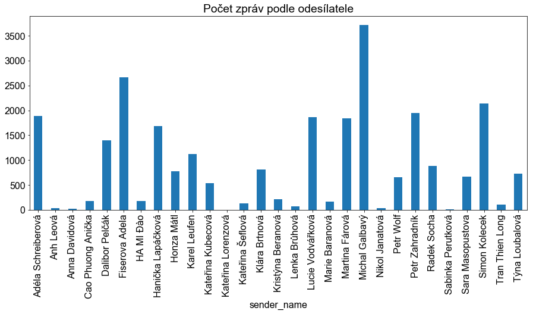

```python
msg_by_sender = msg.groupby('sender_name')
msg_by_sender.content.count().plot.bar(title='Počet zpráv podle odesílatele')
#msg[msg.content == msg.content]
```

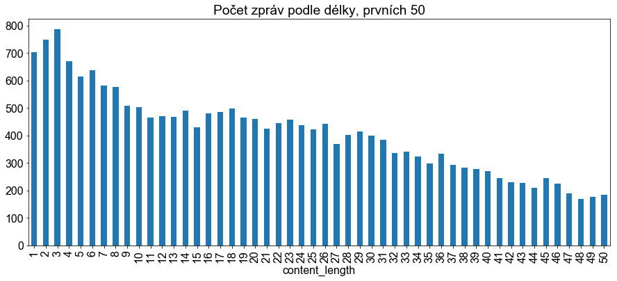

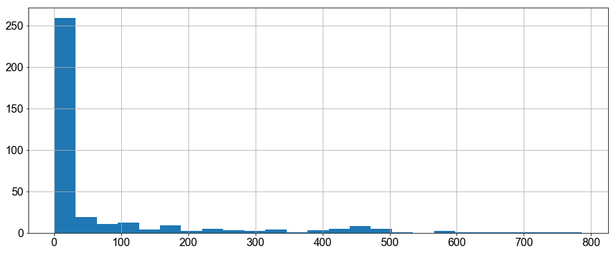

```python
msg['content_length'] = msg.content.apply(lambda x: len(x))
msg.groupby('content_length').content.count().loc[1:50].plot.bar(title='Počet zpráv podle délky, prvních 50')
plt.show()
msg.groupby('content_length').content.count().hist(bins=25)
```

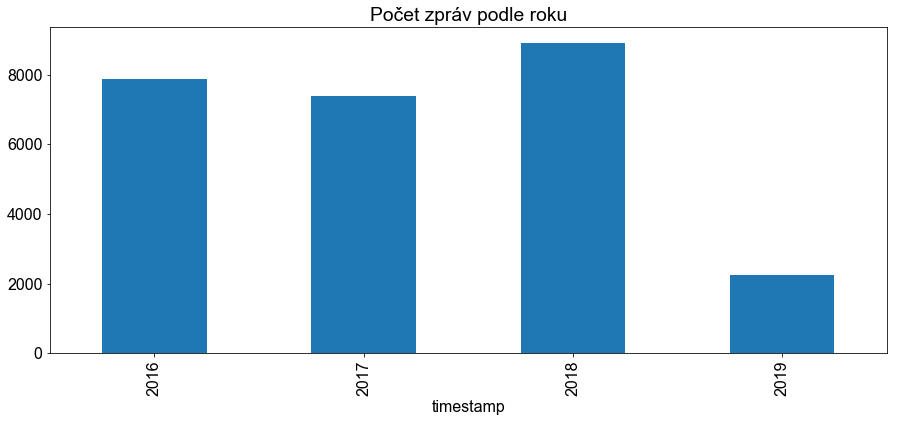

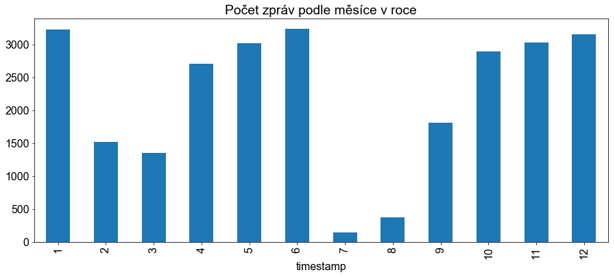

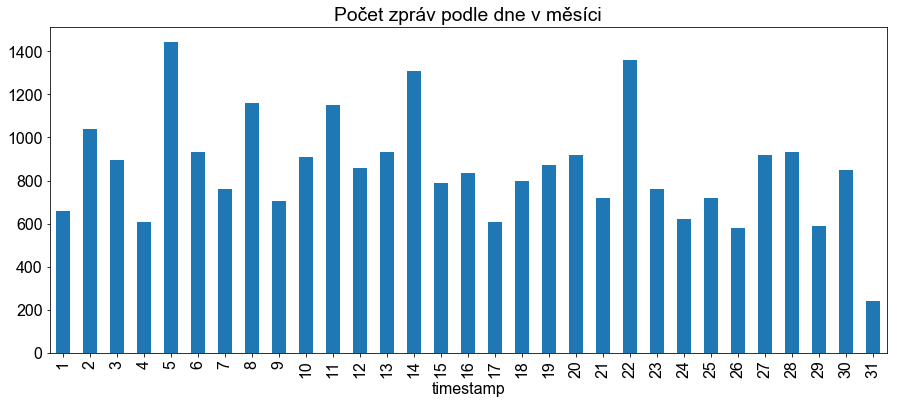

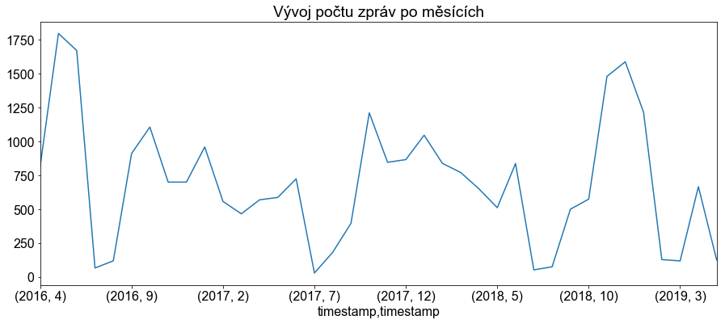

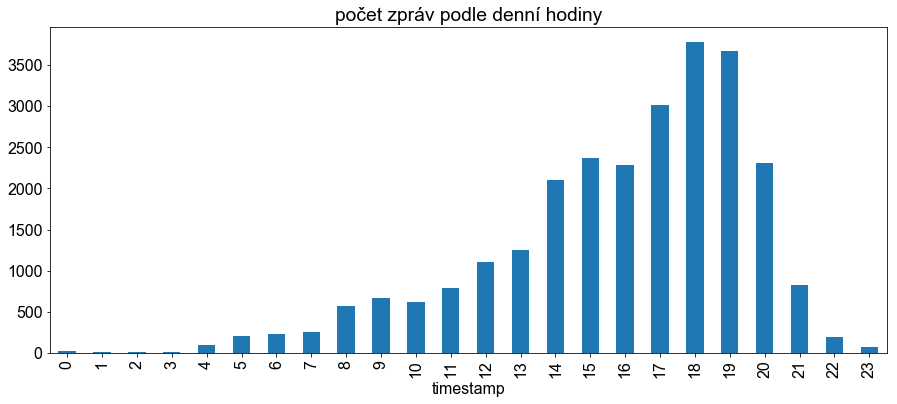

```python
msg['timestamp'] = pd.to_datetime(msg.timestamp_ms, unit='ms')
msg.groupby(msg.timestamp.dt.year).timestamp.count().plot.bar(title='Počet zpráv podle roku')
plt.show()
msg.groupby(msg.timestamp.dt.month).timestamp.count().plot.bar(title='Počet zpráv podle měsíce v roce')
plt.show()
msg.groupby(msg.timestamp.dt.day).timestamp.count().plot.bar(title='Počet zpráv podle dne v měsíci')
plt.show()
msg.groupby([msg.timestamp.dt.year, msg.timestamp.dt.month]).timestamp.count().plot(title='Vývoj počtu zpráv po měsících')
plt.show()
msg.groupby(msg.timestamp.dt.hour).timestamp.count().plot.bar(title='počet zpráv podle denní hodiny')
plt.show()
```

[output not shown]

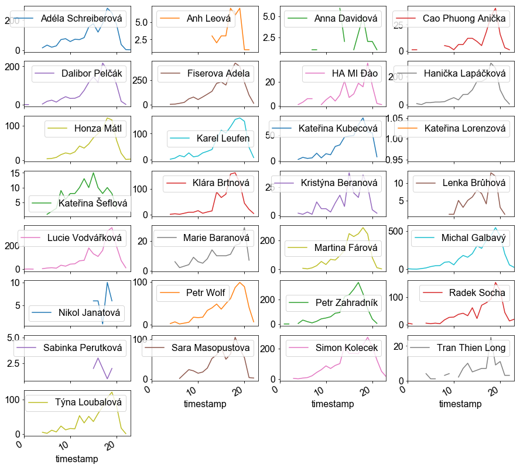

```python
msg_groupby_name_hour = msg.groupby([msg.sender_name, msg.timestamp.dt.hour]).content.count()

msg_groupby_name_hour.unstack('sender_name').plot(subplots=True, layout=(8,4), figsize=(15,15))
```

[figure not shown]

```python
msg['content_words'] = msg.content.str.split().dropna()
words_list = msg.content.str.cat(sep = ' ').split()
words = pd.Series( (v for v in words_list) )
words.dropna().groupby(words).count().sort_values(ascending=False)[20:0:-1].plot.barh(title='TOP 20 nejpoužívanějších slov')
#msg.content_words.str.cat().dropna()
#msg_groupby_content_words
```

```python
print('TOP 10 nejčastějších slov podle odesílatele:')
names = (name for name, group in msg.groupby(msg.sender_name).content)
words = (np.array(
    pd.Series(group.str.cat(sep = ' ').split())
    .groupby(pd.Series(group.str.cat(sep = ' ').split()))
    .count()
    .sort_values(ascending=False)[0:10].index)
    for name, group in msg.groupby(msg.sender_name).content)
words_by_sender = pd.DataFrame(words, index = names)
words_by_sender
```

```
TOP 10 nejčastějších slov podle odesílatele:
```

|  | 0 | 1 | 2 | 3 | 4 | 5 | 6 | 7 | 8 | 9 |
| --- | --- | --- | --- | --- | --- | --- | --- | --- | --- | --- |
| Adéla Schreiberová | to | :-D | se | na | a | je | v | z | mi | :-) |
| Anh Leová | v | Radek | hlasovala | pro: | anketě | ja | chci | taky | bych | z |
| Anna Davidová | v | hlasovala | Radek | pro: | anketě | na | to | tak | chci | je |
| Cao Phuong Anička | to | v | hlasovala | pro: | anketě | Radek | se | na | ze | Ja |
| Dalibor Pelčák | to | na | a | se | je | v | tak | že | si | z |
| Fiserova Adela | to | na | je | a | se | v | tak | si | ze | z |
| HA MI Đào | to | Radek | na | v | se | ze | tam | anketě | pro: | hlasovala |
| Hanička Lapáčková | to | na | a | je | ze | tak | se | v | si | z |
| Honza Mátl | to | na | Kč | a | je | že | v | se | 3*2=5 | 500,00 |
| Karel Leufen | to | se | že | je | Já | na | v | a | Radek | jsem |
| Kateřina Kubecová | to | na | :D | a | ze | se | v | je | si | tak |
| Kateřina Lorenzová | skupinu. | opustil(a) | Lorenzová | Kateřina | None | None | None | None | None | None |
| Kateřina Šeflová | v | to | na | se | a | Radek | anketě | hlasovala | pro: | ze |
| Klára Brtnová | to | na | je | No | tak | v | se | To | a | ale |
| Kristýna Beranová | na | to | Radek | v | Ja | a | je | pro: | hlasovala | anketě |
| Lenka Brůhová | v | Radek | anketě | pro: | hlasovala | a | to | na | Já | :D |
| Lucie Vodvářková | to | na | se | a | je | Ja | v | ze | tam | z |
| Marie Baranová | to | na | se | v | ze | Radek | a | anketě | hlasovala | pro: |
| Martina Fárová | to | na | se | ze | a | je | v | A | tam | tak |
| Michal Galbavý | to | na | a | se | je | v | z | si | jsem | Radek |
| Nikol Janatová | a | to | :) | na | se | taky | jen | pak | v | A |
| Petr Wolf | to | na | v | se | je | že | si | Radek | A | a |
| Petr Zahradník | to | na | a | se | :) | je | v | :D | že | tak |
| Radek Socha | to | na | Zadek | 😵 | v | je | se | A | si | a |
| Sabinka Perutková | Sabinka | v | pro: | hlasovala | anketě | :) | pro | matiku? | Videochat | skončil. |
| Sara Masopustova | to | na | se | je | a | ze | v | tak | ale | si |
| Simon Kolecek | to | na | se | 😂 | Radek | je | a | že | v | 😁 |
| Tran Thien Long | v | na | Radek | anketě | pro: | hlasoval | Ahoj | Díky | ? | všichni |
| Týna Loubalová | to | na | a | se | je | by | někdo | v | 😃 | z |

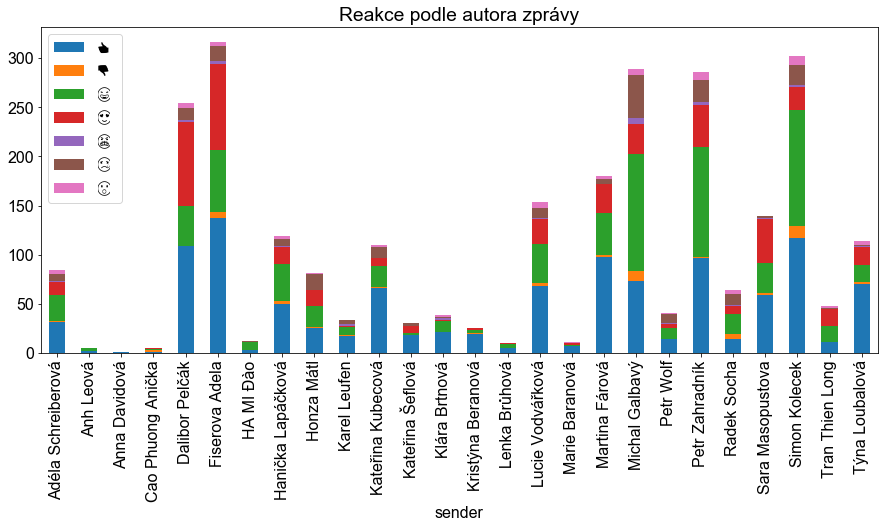

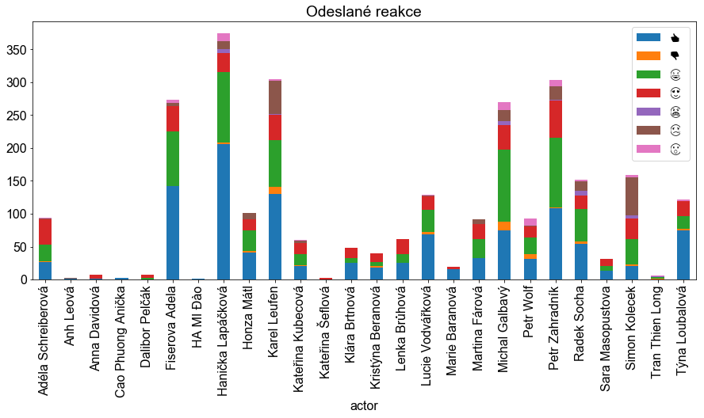

```python
reactions = pd.DataFrame(
    {'sender': message.get('sender_name'),
     'reaction': reaction.get('reaction'),
     'actor': reaction.get('actor')
    } for message in json_raw['messages'] if message.get('reactions') for reaction in message.get('reactions'))

ax = reactions.groupby(['sender', 'reaction']).count().unstack().plot(kind='bar', stacked=True, title='Reakce podle autora zprávy')
legend = ax.legend(['👍', '👎', '😆', '😍', '😠', '😢', '😮'], prop={'family': 'Segoe UI Symbol', 'size': 15})
plt.show()

ax = reactions.groupby(['actor', 'reaction']).count().unstack().plot(kind='bar', stacked=True, title='Odeslané reakce')
legend = ax.legend(['👍', '👎', '😆', '😍', '😠', '😢', '😮'], prop={'family': 'Segoe UI Symbol', 'size': 15})
plt.show()
```